# Control y Descontrol

## ¿Qué ha hecho posible el crecimiento de las ERNC?

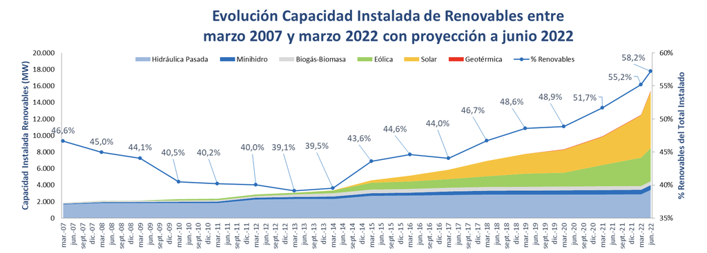

Fuente: Ministerio de Energía, Reporte de proyectos en Construcción e Inversión, 2022.

- **Subsidios e incentivos:** muchos países han creado incentivos para la producción y adopción de ERNC: subsidios, inversiones en I+D, créditos tributarios
- **Cambios regulatorios:** incorporación de la posibilidad de vender excedentes a distribuidoras (*net-metering*)
- **Learning-by-doing:** mientras más hacemos, mejor lo hacemos — la curva de costos cae

## La curva de aprendizaje

[figure not shown]

Learning-by-doing: la reducción de costos de las energías renovables a medida que se acumula experiencia y escala de producción.

## Pero la transición necesita minerales…

La transición energética requiere enormes cantidades de **cobre, litio, cobalto, níquel y tierras raras**

Un auto eléctrico necesita ~6 veces más minerales que uno convencional. Una planta eólica offshore necesita ~13 veces más minerales que una planta de gas natural de capacidad equivalente

Chile es el **mayor productor mundial de cobre** y el **segundo de litio**

¿Cuáles son los costos de extraer estos minerales? ¿Quiénes pagan las consecuencias?

## Tensiones en el futuro verde del litio

Las siguientes diapositivas están basadas en el artículo del CR2 (2025): [“¿Hacia una nueva zona de sacrificio? Fiebre del litio y desconfianza indígena”](https://www.cr2.cl/hacia-una-nueva-zona-de-sacrificio-fiebre-del-litio-y-desconfianza-indigena-tercera-dosis/)

Una mirada crítica a las tensiones entre la transición energética y los derechos de las comunidades y ecosistemas del norte de Chile

## La fiebre del litio

El litio es esencial para las **baterías** de autos eléctricos, almacenamiento de energía y electrónica

En Chile se extrae principalmente del **Salar de Atacama**, mediante evaporación de **salmuera** (brine)

La Estrategia Nacional del Litio (2023) busca expandir la producción a nuevos salares: Maricunga, Pedernales, Aguilar

**El problema del agua**

- La extracción de salmuera consume enormes volúmenes de agua en una de las zonas **más áridas del planeta**
- En la Región de Antofagasta, el **95%** de los derechos de agua subterránea están en manos de la minería (DGA, 2009)
- La cuenca del Río Loa fue declarada **agotada** en el año 2000
- En 2022, 188 comunas chilenas (47,5% de la población) tenían decretos de escasez hídrica

## Litio y comunidades indígenas

Los salares donde se extrae litio son **territorios ancestrales** de los pueblos Atacameño y Colla

Chile ratificó el **Convenio OIT 169**, que obliga a consultar a los pueblos indígenas afectados. Sin embargo, la consulta:

- No es vinculante
- Tiene plazos comprimidos
- Excluye a comunidades no adyacentes a los salares

Las comunidades indígenas desconfían porque **ya vivieron esto con el cobre**:

- En los 80, fueron desinformadas sobre el registro de derechos de agua
- CODELCO canalizó completamente el Río San Pedro
- Entre 1997–2000 hubo contaminación con plomo y arsénico en el Loa

¿Se repetirá la historia con el litio?

## ¿Hacia una nueva zona de sacrificio?

**Ecosistemas frágiles**

- Solo el **30%** de los salares está en la Red de Salares Protegidos
- Solo el **4,07%** de los humedales andinos de Antofagasta tiene protección
- Las vegas y bofedales — ecosistemas únicos — dependen del mismo acuífero que la minería

**Vacío regulatorio**

La salmuera está clasificada legalmente como **mineral**, no como agua — lo que permite extraerla sin las restricciones del Código de Aguas

Esto crea un punto ciego regulatorio: se extrae agua sin que cuente como extracción de agua

## ¿Puede ser diferente esta vez?

**Lo que es distinto hoy**

- Chile ratificó el **Convenio 169 de la OIT** (2008) — obligación legal de consulta indígena
- Tecnologías de **extracción directa de litio** (DLE) prometen usar menos agua que la evaporación
- Presión internacional de las **cadenas de suministro** (UE exige trazabilidad ambiental y social)
- Mayor conciencia ambiental y herramientas de monitoreo (datos satelitales, SIG)

# Presentación Tarea 05

## Tarea 05: Energías Renovables — Control y Descontrol

**¿Qué van a construir?**

Un **díptico** con dos mapas:

1. **Mapa mundial** de energías renovables como porcentaje de la matriz eléctrica
2. **Mapa de Sudamérica** con minas de litio y zonas de estrés hídrico

Una historia de Control y Descontrol: el avance renovable… y su costo oculto

**Herramientas nuevas:**

- Importación de datos CSV (con y sin coordenadas)
- Join no espacial (combinar tablas)
- Exportación de capas a GeoPackage
- Simbología basada en reglas (clase “Sin información”)
- Composición de impresión con dos mapas (díptico)
- Edición avanzada de leyendas

## Entregable

Un **díptico horizontal** (paisaje) con ambos mapas, exportado como imagen o PDF desde el compositor de impresión de QGIS

La guía paso a paso y el archivo `.zip` con los datos están disponibles en Canvas.

## Próxima clase

La próxima semana exploraremos:

- **Minería en Chile** — la importancia económica y los costos ambientales
- **Relaves mineros** — qué son, por qué son peligrosos, y dónde están
- **Contaminación de suelos** — más allá de la minería
- **Herramientas GIS**: buffers y uniones espaciales

Lectura para la próxima clase: artículo de **CIPER** sobre relaves bajo el cambio climático.